## LOAD LIBRARIES

```r
library(data.table)
library(dataplumbr)
library(tidycensus)
library(sf)
library(ggplot2)
library(here)
library(knitr)
library(kableExtra)
```

## DSS RECORDS

Load DSS records and standardize column names

```r
dss_customers_by_year <- fread(here("data/original/q4/DSS/DSS Customers By Year.csv"), colClasses = "character")
colnames(dss_customers_by_year) <- standard_col_names(colnames(dss_customers_by_year))
```

fix a misspelling for future joining

```r
colnames(dss_customers_by_year)[colnames(dss_customers_by_year) == "calender_year_number"] <- "calendar_year_number"
```

subset to just the data columns needed

```r
dss_customers_by_year_sub <-
  dss_customers_by_year[, .(unique_id,
                            calendar_year_number,
                            snap_case_indicator,
                            tanf_case_indicator,
                            foster_care_case_indicator)]
# print table
kable(dss_customers_by_year[1:4]) %>% kable_styling() %>% scroll_box(width = "910px")
```

| unique_id | study_group_id | age_class_code | age_group_code | age_type_code | month_of_birth | year_of_birth | school_type_code | ethnicity_code | foster_care_case_indicator | gender_code | cust_race_is_amer_indian_alaska_native_ind | customer_race_is_asisan_indicator | customer_race_is_black_indicator | cust_race_is_hawaiian_pacific_islander_ind | customer_race_is_other_indicator | customer_race_is_white_indicator | snap_case_indicator | tanf_case_indicator | calendar_year_number |
| --- | --- | --- | --- | --- | --- | --- | --- | --- | --- | --- | --- | --- | --- | --- | --- | --- | --- | --- | --- |
| 3CLXQQQ | 127655 | 2 | 08 | 3 | 08 | 1992 | 06 | 2 | N | 1 | N | N | N | N | N | N | Y | Y | 2013 |
| MV4WQQQ | 42810 | 2 | 10 | 3 | 03 | 1986 | 0 | 2 | N | 2 | N | N | Y | N | N | N | Y | Y | 2013 |
| HVYPQQQ | 936757 | 2 | 09 | 3 | 10 | 1991 | 0 | 2 | N | 1 | N | N | Y | N | N | N | Y | Y | 2013 |
| H484QQQ | 288469 | 2 | 10 | 3 | 04 | 1988 | 0 | 2 | N | 1 | N | N | Y | N | N | N | Y | Y | 2013 |

## OCS RECORDS

Load OCS records and standardize column names

```r
ocs_services_by_year <- fread(here("data/original/q4/OCS/OCS Services By Year.csv"), colClasses = "character")
colnames(ocs_services_by_year) <- standard_col_names(colnames(ocs_services_by_year))
```

Group the OCS service records by year to create a single record per customer per year

```r
ocs_customers_by_year <- ocs_services_by_year[, .(ocs_service_entries = .N), .(unique_id, program_year)]
# print table
kable(ocs_customers_by_year[1:4]) %>% kable_styling() %>% scroll_box(width = "910px")
```

| unique_id | program_year | ocs_service_entries |
| --- | --- | --- |
| MZ4CQQQ | 2016 | 2 |
| 2942AQQ | 2016 | 2 |
| K929QQQ | 2016 | 1 |
| GHCHQQQ | 2016 | 2 |

## Join the DSS and OCS records

```r
colnames(ocs_customers_by_year)[colnames(ocs_customers_by_year) == "program_year"] <- "calendar_year_number"
dss_ocs_cust_by_year <- merge(dss_customers_by_year_sub, ocs_customers_by_year, by = c("unique_id", "calendar_year_number"), all.x = TRUE)
```

add a service indicator variable for later use

```r
dss_ocs_cust_by_year[!is.na(ocs_service_entries), ocs_indicator := "Y"]
dss_ocs_cust_by_year[is.na(ocs_service_entries), ocs_indicator := "N"]
```

## SNAP RECORDS

Load SNAP records and standardize column names

```r
snap_cust_by_loc_year <- fread(here("data/original/q4/DSS/DSS SNAP Customers by Year.csv"), colClasses = "character")
colnames(snap_cust_by_loc_year) <- standard_col_names(colnames(snap_cust_by_loc_year))
```

### SNAP records are actually Customer by Year by “Location”, so multiple records per customer

if they received benefits in more than one fips code or zip code. As a single record is needed per customer, additional columns must be created to account for all possible locations. The number of columns added is based on the customer with the highest number of locations in a single year. In this case it is six, but the code automatically determines the number.

```r
# each county fips code gets it's own column, each zip code gets its own column
snap_cust_by_loc_year[, county_fips_code_no := paste("county_fips_code", seq_len(.N), sep="_"), by=c("unique_id", "study_group_id", "calendar_year_number")]
snap_cust_by_loc_year[, zip_code_no := paste("zip_code", seq_len(.N), sep="_"), by=c("unique_id", "study_group_id", "calendar_year_number")]
fips <- dcast(snap_cust_by_loc_year, unique_id + study_group_id + calendar_year_number ~ county_fips_code_no, value.var=c("county_fips_code"))
zips <- dcast(snap_cust_by_loc_year, unique_id + study_group_id + calendar_year_number ~ zip_code_no, value.var=c("zip_code"))
snap_cust_by_year <- merge(fips, zips, by=c("unique_id", "study_group_id", "calendar_year_number"))
# print table
kable(snap_cust_by_year[!is.na(county_fips_code_5)][order(-county_fips_code_6)][1:25]) %>% kable_styling() %>% scroll_box(width = "100%")
```

| unique_id | study_group_id | calendar_year_number | county_fips_code_1 | county_fips_code_2 | county_fips_code_3 | county_fips_code_4 | county_fips_code_5 | county_fips_code_6 | zip_code_1 | zip_code_2 | zip_code_3 | zip_code_4 | zip_code_5 | zip_code_6 |
| --- | --- | --- | --- | --- | --- | --- | --- | --- | --- | --- | --- | --- | --- | --- |
| 8AXYQQQ | 561563 | 2007 | 159 | 690 | 770 | 540 | 760 | 790 | 23219 | 24114 | 24013 | 22902 | 22801 | 22902 |
| 8AXYQQQ | 561563 | 2009 | 187 | 660 | 630 | 153 | 165 | 650 | 22603 | 22664 | 23970 | 22402 | 22664 | 23663 |
| XA9SQQQ | 93574 | 2014 | 099 | 179 | 159 | 047 | 700 | 193 | 22485 | 22556 | 22572 | 22701 | 23606 | 22469 |
| 73TSAQQ | 1129047 | 2014 | 700 | 047 | 099 | 193 | 159 | 179 | 23606 | 22701 | 22485 | 22469 | 22572 | 22556 |
| CHXRQQQ | 300042 | 2015 | 003 | 065 | 540 | 650 | 710 | 165 | 22902 | 22974 | 22902 | 23663 | 23663 | 22853 |
| XQ7VAQQ | 1430886 | 2015 | 003 | 710 | 650 | 540 | 065 | 165 | 22902 | 23663 | 23663 | 22902 | 22974 | 22853 |
| NCJBQQQ | 515766 | 2012 | 111 | 041 | 029 | 049 | 117 | 133 | 23944 | 23237 | 24553 | 23027 | 23970 | 22511 |
| V8JSAQQ | 1138894 | 2012 | 049 | 029 | 117 | 041 | 111 | 133 | 23027 | 24553 | 23970 | 23237 | 23944 | 22511 |
| BN4BQQQ | 501810 | 2013 | 630 | 770 | 177 | 153 | 137 | 109 | 22401 | 24016 | 23093 | 22026 | 22508 | 23093 |
| ATBRAQQ | 1360737 | 2012 | 117 | 133 | 111 | 041 | 029 | 049 | 23970 | 22511 | 23944 | 23237 | 24553 | 23027 |
| NXB7QQQ | 672310 | 2014 | 099 | 159 | 179 | 193 | 700 | 047 | 22485 | 22572 | 22556 | 22469 | 23606 | 22701 |
| ZS9QAQQ | 978434 | 2013 | 700 | 710 | 159 | 650 | 760 | 041 | 23607 | 23607 | 23607 | 23112 | 23219 | 23112 |
| 22EMQQQ | 760259 | 2007 | 830 | 127 | 700 | 095 | 087 | NA | 23185 | 23011 | 23602 | 23188 | 23231 | NA |
| 233AAQQ | 988739 | 2010 | 171 | 660 | 125 | 165 | 015 | NA | 22842 | 22801 | 22920 | 22815 | 22980 | NA |
| 235RQQQ | 308803 | 2010 | 015 | 790 | 820 | 073 | 199 | NA | 22980 | 23692 | 22980 | 23072 | 23692 | NA |
| 2EQBQQQ | 490083 | 2010 | 177 | 510 | 630 | 059 | 013 | NA | 22408 | 22301 | 22401 | 22307 | 22204 | NA |
| 2GG2QQQ | 16259 | 2010 | 720 | 155 | 195 | 770 | 750 | NA | 24273 | 24084 | 24273 | 24013 | 24141 | NA |
| 2TPRQQQ | 325475 | 2007 | 159 | 103 | 095 | 073 | 097 | NA | 22572 | 22482 | 23187 | 23061 | 23156 | NA |
| 32ASQQQ | 64967 | 2008 | 043 | 171 | 683 | 061 | 187 | NA | 22611 | 22664 | 20186 | 22604 | 22664 | NA |
| 388MQQQ | 780487 | 2014 | 710 | 093 | 700 | 620 | 800 | NA | 23508 | 23851 | 23602 | 23851 | 23439 | NA |
| 39ZRQQQ | 296199 | 2012 | 193 | 177 | 630 | 179 | 153 | NA | 22443 | 22407 | 22401 | 22405 | 22026 | NA |
| 3LDVQQQ | 368935 | 2007 | 093 | 620 | 800 | 041 | 087 | NA | 23898 | 23851 | 23434 | 23112 | 23231 | NA |
| 48R4AQQ | 1322187 | 2012 | 740 | 033 | 760 | 087 | 630 | NA | 23325 | 22514 | 23225 | 23294 | 22401 | NA |
| 4J76AQQ | 1595531 | 2013 | 700 | 810 | 830 | 199 | 650 | NA | 23602 | 23464 | 23185 | 23692 | 23669 | NA |
| 4UBEAQQ | 1229931 | 2013 | 153 | 683 | 047 | 059 | 113 | NA | 20108 | 20110 | 22701 | 22003 | 22727 | NA |

## Join the DSS, OCS and SNAP records

```r
dss_ocs_snap_cust_by_year <- merge(dss_ocs_cust_by_year, snap_cust_by_year, by = c("unique_id", "calendar_year_number"), all.x = TRUE)
```

```r
dss_ocs_snap_cust_by_year <- dss_ocs_snap_cust_by_year[!is.na(county_fips_code_1)]
```

```r
ocs_snap_cnt_fips_by_year <- dss_ocs_snap_cust_by_year[, .N, c("county_fips_code_1", "calendar_year_number")]
# print table
kable(ocs_snap_cnt_fips_by_year[1:4]) %>% kable_styling() %>% scroll_box(width = "910px")
```

| county_fips_code_1 | calendar_year_number | N |
| --- | --- | --- |
| 177 | 2013 | 16514 |
| 177 | 2014 | 16467 |
| 179 | 2015 | 12891 |
| 179 | 2016 | 9394 |

## Get population by county by year for Virginia

```r
va_pop_co_2013 <- data.table::setDT(tidycensus::get_acs(geography = "county", variables = "B01001_001", state = "VA", year = 2013))
va_pop_co_2013[, year := "2013"]
colnames(va_pop_co_2013)[colnames(va_pop_co_2013) == 'estimate'] <- 'estimate_2013'
va_pop_co_2013 <- va_pop_co_2013[, .(GEOID, estimate_2013, year)]

va_pop_co_2014 <- data.table::setDT(tidycensus::get_acs(geography = "county", variables = "B01001_001", state = "VA", year = 2014))
va_pop_co_2014[, year := "2014"]
colnames(va_pop_co_2014)[colnames(va_pop_co_2014) == 'estimate'] <- 'estimate_2014'
va_pop_co_2014 <- va_pop_co_2014[, .(GEOID, estimate_2014, year)]

va_pop_co_2015 <- data.table::setDT(tidycensus::get_acs(geography = "county", variables = "B01001_001", state = "VA", year = 2015))
va_pop_co_2015[, year := "2015"]
colnames(va_pop_co_2015)[colnames(va_pop_co_2015) == 'estimate'] <- 'estimate_2015'
va_pop_co_2015 <- va_pop_co_2015[, .(GEOID, estimate_2015, year)]

va_pop_co_2016 <- data.table::setDT(tidycensus::get_acs(geography = "county", variables = "B01001_001", state = "VA", year = 2016))
va_pop_co_2016[, year := "2016"]
colnames(va_pop_co_2016)[colnames(va_pop_co_2016) == 'estimate'] <- 'estimate_2016'
va_pop_co_2016 <- va_pop_co_2016[, .(GEOID, estimate_2016, year)]
```

## Combine Population Counts for Each Year

```r
colnames(ocs_snap_cnt_fips_by_year) <- c("GEOID", "year", "N")
ocs_snap_cnt_fips_by_year[, GEOID := paste0("51", GEOID)]
ocs_snap_cnt_fips_by_year <- merge(ocs_snap_cnt_fips_by_year, va_pop_co_2013, by = c("GEOID", "year"), all.x = T)
ocs_snap_cnt_fips_by_year <- merge(ocs_snap_cnt_fips_by_year, va_pop_co_2014, by = c("GEOID", "year"), all.x = T)
ocs_snap_cnt_fips_by_year <- merge(ocs_snap_cnt_fips_by_year, va_pop_co_2015, by = c("GEOID", "year"), all.x = T)
ocs_snap_cnt_fips_by_year <- merge(ocs_snap_cnt_fips_by_year, va_pop_co_2016, by = c("GEOID", "year"), all.x = T)
ocs_snap_cnt_fips_by_year[, pop_est := gsub("NA", "", paste0(estimate_2013, estimate_2014, estimate_2015, estimate_2016))]
```

```r
ocs_snap_cnt_fips_by_year <- ocs_snap_cnt_fips_by_year[, .(GEOID, year, snap_plus_ocs = N, pop_est, idx = N/as.numeric(pop_est))]
# print table
kable(ocs_snap_cnt_fips_by_year[1:4]) %>% kable_styling() %>% scroll_box(width = "910px")
```

| GEOID | year | snap_plus_ocs | pop_est | idx |
| --- | --- | --- | --- | --- |
| 51001 | 2013 | 9023 | 33289 | 0.2710505 |
| 51001 | 2014 | 8717 | 33165 | 0.2628373 |
| 51001 | 2015 | 8055 | 33115 | 0.2432432 |
| 51001 | 2016 | 5838 | 33060 | 0.1765880 |

## Create the Nutritional - Behavioral Index Map

Download the Geography

```r
va_geo <- tidycensus::get_acs(geography = "county", variables = "B01001_001", state = "VA", year = 2016, geometry = TRUE)
```

Combine the data and geography and create the map

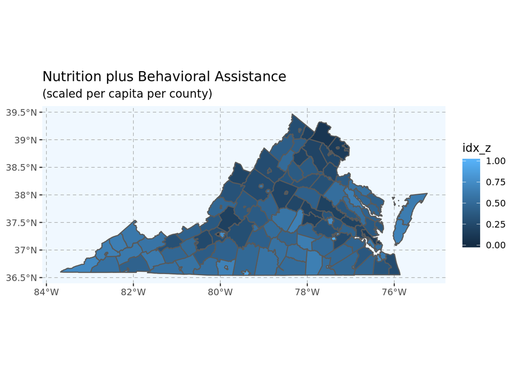

```r
va_geo_idx_2013 <- merge(va_geo, idx_2013, by = "GEOID")

ggplot(data = va_geo_idx_2013) +
  geom_sf(aes(fill = idx_z)) +
  ggtitle("Nutrition plus Behavioral Assistance", subtitle = "(scaled per capita per county)") +
  theme(panel.grid.major = element_line(color = gray(0.5), linetype = "dashed",
                                        size = 0.5), panel.background = element_rect(fill = "aliceblue"))
```